# MA415/615 EDA Project - Refrigerator

Xiaoqian Xue, Sibo Zhu, Li Liu, Yufei Lin, Danni Fu

2017/10/10

# Introduction

In order to find the best plan for marketing the refrigerators in U.S, we explore the EIA data in 2015 RECS Survey. In this project, we focus on the Appliance by Household income (HC 3.5), and the Refrigerator’s size and type in the Northeast and Midwest regions (HC 3.7) and in the South and West regions (HC 3.8).

Different regions may have different demands for the refrigerator size and type. Household living in the rich regions, for example New England or East Coast, may not need a very large refrigerator since they are very close to the market and may buy the more expansive refrigerator with more function. On the contrary, household living in the middle or south may need a large refrigerator with simple design.

To get a more scientific result, we use R to explore the data and plot to see the distributions of the EDA data and provide analysis as following.

## Exploring for different regions

We obtained the data from the Housing Appliances of February 27, 2017 in the Northeast and Midwest regions (HC3.7) and in the South and West regions (HC3.8).

```r
# SUPPRESS GLOBAL WARNING
options(warn = -1)

# SET TO ONE DIGIT AFTER DECIMAL POINT
options(digits = 2)

# PREPARE PACKAGES
if (!require("pacman")) install.packages("pacman")
```

```r
pacman::p_load("dplyr", "ggplot2", "tibble", "tidyr", "readxl", "reshape2")

#downloading data

download.file(
  "https://www.eia.gov/consumption/residential/data/2015/hc/hc3.7.xlsx",
  "NORTH_MID.xlsx", quiet = TRUE, mode = "wb")


download.file(
  "https://www.eia.gov/consumption/residential/data/2015/hc/hc3.8.xlsx",
  "SOUTH_WEST.xlsx", quiet = TRUE, mode = "wb")
```

```r
#selecting data
NM_size <- read_excel("NORTH_MID.xlsx", sheet = "data", range = "A108:H113",
                          col_names = FALSE, col_types = "text")

NM_type <- read_excel("NORTH_MID.xlsx", sheet = "data", range = "A115:H121",
                          col_names = FALSE, col_types = "text")

SW_size <- read_excel("SOUTH_WEST.xlsx", sheet = "data", range = "A111:K116",
                          col_names = FALSE, col_types = "text")

SW_type <- read_excel("SOUTH_WEST.xlsx", sheet = "data", range = "A118:K124",
                          col_names = FALSE, col_types = "text")
```

```r
#create duplicate data for future use
NM_size_1 <- NM_size

NM_type_1 <- NM_type

SW_size_1 <- SW_size

SW_type_1 <- SW_type
```

```r
#rename column's names
colnames(NM_size_1)      <- c("RFG_SIZE", "TTL_US", "TTL_NE",
                           "N_ENG", "MID_ATL", "TTL_MID_WEST",
                           "EN_CENT", "WN_CENT")

colnames(NM_type_1)      <- c("RFG_TYPE", "TTL_US", "TTL_NE",
                           "N_ENG", "MID_ATL", "TTL_MID_WEST",
                           "EN_CENT", "WN_CENT")

colnames(SW_size_1)      <- c("RFG_SIZE", "TTL_US", "TTL_SOUTH",
                           "S_ATL", "ES_CENT", "WS_CENT",
                           "TTL_WEST", "TTL_MOUNT", "MOUNT_N",
                           "MOUNT_SOUTH", "PACIF")

colnames(SW_type_1)      <- c("RFG_TYPE", "TTL_US", "TTL_SOUTH",
                           "S_ATL", "ES_CENT", "WS_CENT",
                           "TTL_WEST", "TTL_MOUNT", "MOUNT_N",
                           "MOUNT_SOUTH", "PACIF")
```

```r
#Saving total column for future use
NM_size_TTL <- within(NM_size_1,rm(TTL_US,N_ENG,MID_ATL,EN_CENT,WN_CENT))
NM_type_TTL <- within(NM_type_1,rm(TTL_US,N_ENG,MID_ATL,EN_CENT,WN_CENT))

SW_size_TTL <- within(SW_size_1,rm(TTL_US,S_ATL,ES_CENT,WS_CENT,TTL_MOUNT,MOUNT_N,MOUNT_SOUTH,PACIF))
SW_type_TTL <- within(SW_type_1,rm(TTL_US,S_ATL,ES_CENT,WS_CENT,TTL_MOUNT,MOUNT_N,MOUNT_SOUTH,PACIF))
```

```r
#Drop the Unnecessary Column

NM_size_2 <- within(NM_size_1, rm(TTL_US,TTL_NE,TTL_MID_WEST))
NM_type_2 <- within(NM_type_1, rm(TTL_US,TTL_NE,TTL_MID_WEST))
SW_size_2 <- within(SW_size_1, rm(TTL_US,TTL_SOUTH,TTL_WEST,TTL_MOUNT))
SW_type_2 <- within(SW_type_1, rm(TTL_US,TTL_SOUTH,TTL_WEST,TTL_MOUNT))
```

```r
# COERCE FRIDGE TYPE COLUMN TO FACTOR
NM_size_2$RFG_SIZE    <- as.factor(NM_size_2$RFG_SIZE)
NM_type_2$RFG_TYPE    <- as.factor(NM_type_2$RFG_TYPE)
SW_size_2$RFG_SIZE    <- as.factor(SW_size_2$RFG_SIZE)
SW_type_2$RFG_TYPE    <- as.factor(SW_type_2$RFG_TYPE)

NM_size_TTL$RFG_SIZE    <- as.factor(NM_size_TTL$RFG_SIZE)
NM_type_TTL$RFG_TYPE    <- as.factor(NM_type_TTL$RFG_TYPE)
SW_size_TTL$RFG_SIZE    <- as.factor(SW_size_TTL$RFG_SIZE)
SW_type_TTL$RFG_TYPE    <- as.factor(SW_type_TTL$RFG_TYPE)
```

```r
#cleaning data, mark unknown data as N/A
NM_size_2[, 2:5]    <- sapply(NM_size_2[, 2:5], as.numeric)
NM_type_2[, 2:5]    <- sapply(NM_type_2[, 2:5], as.numeric)
SW_size_2[, 2:7]    <- sapply(SW_size_2[, 2:7], as.numeric)
SW_type_2[, 2:7]    <- sapply(SW_type_2[, 2:7], as.numeric)
NM_size_TTL[, 2:3]    <- sapply(NM_size_TTL[, 2:3], as.numeric)
NM_type_TTL[, 2:3]    <- sapply(NM_type_TTL[, 2:3], as.numeric)

SW_size_TTL[, 2:3]    <- sapply(SW_size_TTL[, 2:3], as.numeric)
SW_type_TTL[, 2:3]    <- sapply(SW_type_TTL[, 2:3], as.numeric)
```

```r
#rename columns
colnames(NM_size_2)      <- c("RFG_SIZE",
                           "N_ENG", "MID_ATL",
                           "EN_CENT", "WN_CENT")

colnames(NM_type_2)      <- c("RFG_TYPE",
                           "N_ENG", "MID_ATL",
                           "EN_CENT", "WN_CENT")

colnames(SW_size_2)      <- c("RFG_SIZE",
                           "S_ATL", "ES_CENT", "WS_CENT",
                           "MOUNT_N",
                           "MOUNT_SOUTH", "PACIF")

colnames(SW_type_2)      <- c("RFG_TYPE",
                           "S_ATL", "ES_CENT", "WS_CENT",
                           "MOUNT_N",
                           "MOUNT_SOUTH", "PACIF")
```

```r
#Melting Data
NM_size_3 <- as_tibble(melt(NM_size_2, id = 1))
NM_type_3 <- as_tibble(melt(NM_type_2, id = 1))
SW_size_3 <- as_tibble(melt(SW_size_2, id = 1))
SW_type_3 <- as_tibble(melt(SW_type_2, id = 1))
NM_size_TTL <- as_tibble(melt(NM_size_TTL, id = 1))
NM_type_TTL <- as_tibble(melt(NM_type_TTL, id = 1))
SW_size_TTL <- as_tibble(melt(SW_size_TTL, id = 1))
SW_type_TTL <- as_tibble(melt(SW_type_TTL, id = 1))
```

```r
#Update column's name
names(NM_size_3)[2]    <- "Region"
names(NM_type_3)[2]    <- "Region"
names(SW_size_3)[2]    <- "Region"
names(SW_type_3)[2]    <- "Region"
names(NM_size_TTL)[2]    <- "Region"
names(NM_type_TTL)[2]    <- "Region"
names(SW_size_TTL)[2]    <- "Region"
names(SW_type_TTL)[2]    <- "Region"

####

names(NM_size_3)[3]    <- "Number of Unit"
names(NM_type_3)[3]    <- "Number of Unit"
names(SW_size_3)[3]    <- "Number of Unit"
names(SW_type_3)[3]    <- "Number of Unit"
names(NM_size_TTL)[3]    <- "Number of Unit"
names(NM_type_TTL)[3]    <- "Number of Unit"
names(SW_size_TTL)[3]    <- "Number of Unit"
names(SW_type_TTL)[3]    <- "Number of Unit"
```

```r
#getting sum of data
NM_size_SUM <- aggregate(NM_size_3$`Number of Unit`,
                           by = list(category = NM_size_3$`Region`),
                           FUN=sum, na.rm = TRUE)

NM_type_SUM <- aggregate(NM_type_3$`Number of Unit`,
                           by = list(category = NM_type_3$`Region`),
                           FUN=sum, na.rm = TRUE)

SW_size_SUM <- aggregate(SW_size_3$`Number of Unit`,
                           by = list(category = SW_size_3$`Region`),
                           FUN=sum, na.rm = TRUE)

SW_type_SUM <- aggregate(SW_type_3$`Number of Unit`,
                           by = list(category = SW_type_3$`Region`),
                           FUN=sum, na.rm = TRUE)
```

```r
#Rename Columns
names(NM_size_SUM)[1] <- "Region"
names(NM_size_SUM)[2] <- "Total Number of Unit"

names(NM_type_SUM)[1] <- "Region"
names(NM_type_SUM)[2] <- "Total Number of Unit"

names(SW_size_SUM)[1] <- "Region"
names(SW_size_SUM)[2] <- "Total Number of Unit"

names(SW_type_SUM)[1] <- "Region"
names(SW_type_SUM)[2] <- "Total Number of Unit"
```

```r
#Merge Sum with Original Data
TTL_NM_size <- merge(x = NM_size_3, y = NM_size_SUM, by = "Region", all = TRUE)
names(TTL_NM_size)[3] <- "Number of Unit"
names(TTL_NM_size)[4] <- "Total Number of Unit by Region"
TTL_NM_size$Percentage <- 100*(TTL_NM_size$`Number of Unit` /TTL_NM_size$`Total Number of Unit by Region`)
rm(list = ls(pattern = "^T_"))

TTL_NM_type <- merge(x = NM_type_3, y = NM_type_SUM, by = "Region", all = TRUE)
names(TTL_NM_type)[3] <- "Number of Unit"
names(TTL_NM_type)[4] <- "Total Number of Unit by Region"
TTL_NM_type$Percentage <- 100*(TTL_NM_type$`Number of Unit` /TTL_NM_type$`Total Number of Unit by Region`)
rm(list = ls(pattern = "^T_"))

TTL_SW_size <- merge(x = SW_size_3, y = SW_size_SUM, by = "Region", all = TRUE)
names(TTL_SW_size)[3] <- "Number of Unit"
names(TTL_SW_size)[4] <- "Total Number of Unit by Region"
TTL_SW_size$Percentage <- 100*(TTL_SW_size$`Number of Unit` /TTL_SW_size$`Total Number of Unit by Region`)
rm(list = ls(pattern = "^T_"))

TTL_SW_type <- merge(x = SW_type_3, y = SW_type_SUM, by = "Region", all = TRUE)
names(TTL_SW_type)[3] <- "Number of Unit"
names(TTL_SW_type)[4] <- "Total Number of Unit by Region"
TTL_SW_type$Percentage <- 100*(TTL_SW_type$`Number of Unit` /TTL_SW_type$`Total Number of Unit by Region`)
rm(list = ls(pattern = "^T_"))

TTL_size <- merge(x = NM_size_TTL, y = SW_size_TTL, by = c("RFG_SIZE","Region","Number of Unit"), all = TRUE)
TTL_type <- merge(x = NM_type_TTL, y = SW_type_TTL, by = c("RFG_TYPE","Region","Number of Unit"), all = TRUE)
rm(list = ls(pattern = "^T_"))
```

```r
#Start plotting
PLOT_NM_SIZE_PERC <- ggplot(data = TTL_NM_size, aes(x = `Region`, y = Percentage)) +
                 geom_col(aes(fill = `RFG_SIZE`)) +
                 labs(title = "Percentage of Northeast and Midwest regions, 2015") +
                 coord_flip()

PLOT_NM_SIZE <- ggplot(data = TTL_NM_size, aes(x = `Region`, y = `Number of Unit`)) +
             geom_col(aes(fill = `RFG_SIZE`)) +
             theme(axis.text.x = element_text(angle = 90, vjust = 0.5, hjust=1)) +
             labs(title = "Appliances in homes in the Northeast and Midwest regions, 2015")

PLOT_NM_TYPE_PERC <- ggplot(data = TTL_NM_type, aes(x = `Region`, y = Percentage)) +
                 geom_col(aes(fill = `RFG_TYPE`)) +
                 labs(title = "Percentage of Northeast and Midwest regions, 2015") +
                 coord_flip()

PLOT_NM_TYPE <- ggplot(data = TTL_NM_type, aes(x = `Region`, y = `Number of Unit`)) +
             geom_col(aes(fill = `RFG_TYPE`)) +
             theme(axis.text.x = element_text(angle = 90, vjust = 0.5, hjust=1)) +
             labs(title = "Appliances in homes in the Northeast and Midwest regions, 2015")

###########

PLOT_SW_SIZE_PERC <- ggplot(data = TTL_SW_size, aes(x = `Region`, y = Percentage)) +
                 geom_col(aes(fill = `RFG_SIZE`)) +
                 labs(title = "Percentage of South and West regions, 2015") +
                 coord_flip()

PLOT_SW_SIZE <- ggplot(data = TTL_SW_size, aes(x = `Region`, y = `Number of Unit`)) +
             geom_col(aes(fill = `RFG_SIZE`)) +
             theme(axis.text.x = element_text(angle = 90, vjust = 0.5, hjust=1)) +
             labs(title = "Appliances in homes in the South and West regions, 2015")

PLOT_SW_TYPE_PERC <- ggplot(data = TTL_SW_type, aes(x = `Region`, y = Percentage)) +
                 geom_col(aes(fill = `RFG_TYPE`)) +
                 labs(title = "Percentage of South and West regions, 2015") +
                 coord_flip()

PLOT_SW_TYPE <- ggplot(data = TTL_SW_type, aes(x = `Region`, y = `Number of Unit`)) +
             geom_col(aes(fill = `RFG_TYPE`)) +
             theme(axis.text.x = element_text(angle = 90, vjust = 0.5, hjust=1)) +
             labs(title = "Appliances in homes in the South and West regions, 2015")

######

PLOT_SIZE_TTL <- ggplot(data = TTL_size, aes(x = `Region`, y = `Number of Unit`)) +
             geom_col(aes(fill = `RFG_SIZE`)) +
             theme(axis.text.x = element_text(angle = 90, vjust = 0.5, hjust=1)) +
             labs(title = "Appliances of refrigerator size in homes in U.S big regions, 2015")

PLOT_TYPE_TTL <- ggplot(data = TTL_type, aes(x = `Region`, y = `Number of Unit`)) +
             geom_col(aes(fill = `RFG_TYPE`)) +
             theme(axis.text.x = element_text(angle = 90, vjust = 0.5, hjust=1)) +
             labs(title = "Appliances of refrigerator type in homes in U.S big regions, 2015")
```

First, we compared the appliances of refrigerator size in homes in overall U.S regions by using the ggplot. The refrigerator sizes include small (less than 17.6 cubic feet), medium (17.6 to 22.5 cubic feet), large (22.6 to 29.5 cubic feet) and very large (more than 29.5 cubic feet). The vertical axis is the number of housing unit and the horizontal axis is four regions, total northeast, total Midwest plus Middle Atlantic, Total South and Total West. It is clearly shown in the ggplot that most household in the U.S. use the medium and large size refrigerator. There is no big difference between different regions in the size of refrigerator used by households. Only a small amount of household uses the small size and approximately none of the household use very large or do not use a refrigerator.

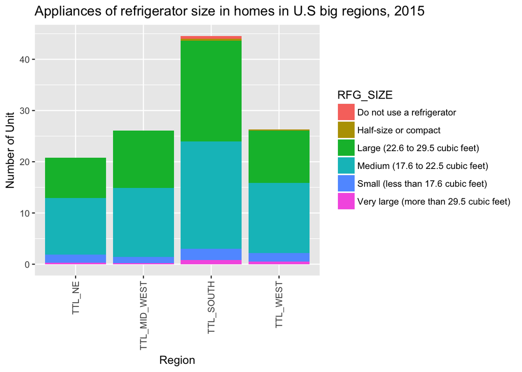

```r
PLOT_SIZE_TTL
```

Next, we focus on the total northeast, total Midwest regions, specifically New England, Middle Atlantic, East North Central and West North Central. We find out that all surveyed households us a refrigerator and none of the surveyed households use half-size or compact refrigerator or very large size refrigerator. Medium and large size refrigerator are more popular in those 4 regions compared to the small size.

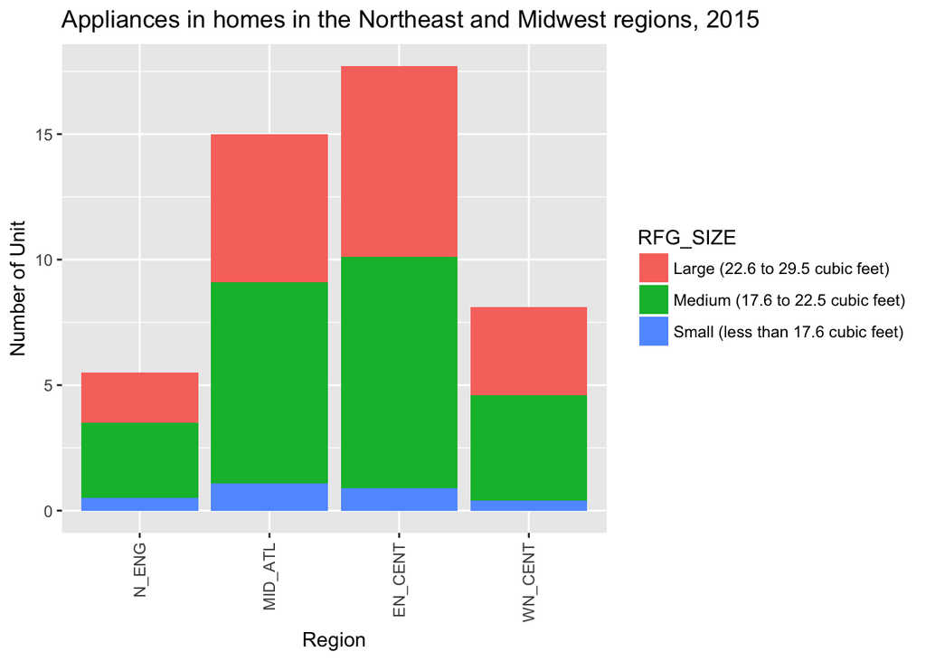

```r
PLOT_NM_SIZE
```

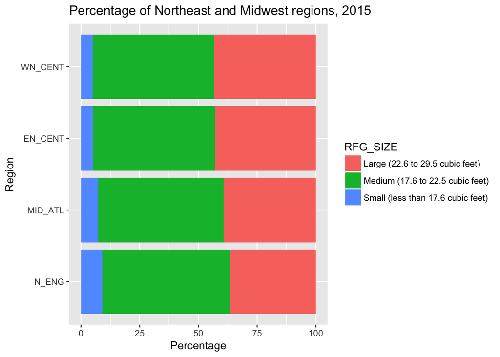

```r
PLOT_NM_SIZE_PERC
```

Then we focus on the South and West regions, specifically South Atlantic, East South Central, West South Central, Mountain North, Mountain South and Pacific. Only tiny number of households use the half-size or compact, small size or very large size refrigerator. In the South Atlantic and West Central, the large and medium size are both popular. However, in the East South Central and Pacific, medium size refrigerator seems more popular. The ggplot also shows that the distribution of Mountain North and South are similar in which the large size and the medium size refrigerator equally dominate.

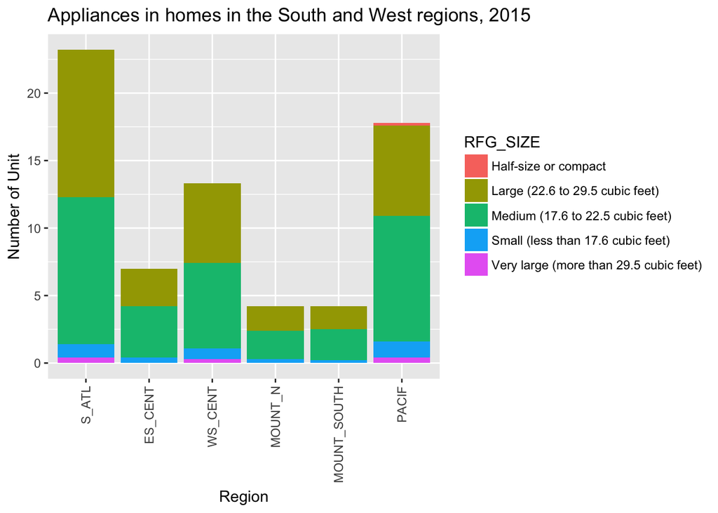

```r
PLOT_SW_SIZE
```

To get a more accurate information to confirm the previous observation, we also calculate the percentage of the number of households using specific size by the total number of households in different regions. Then we use the ggplot to compare the difference in the South and West Regions. We find out medium size refrigerator is the most popular in the Pacific, Mountain South, Mountain North and East Central. For West Central and South Atlantic, the medium size and large size refrigerator are equally popular. Therefore, we can market the medium size refrigerator in all South and West regions and the large size refrigerator in West Central and South Atlantic.

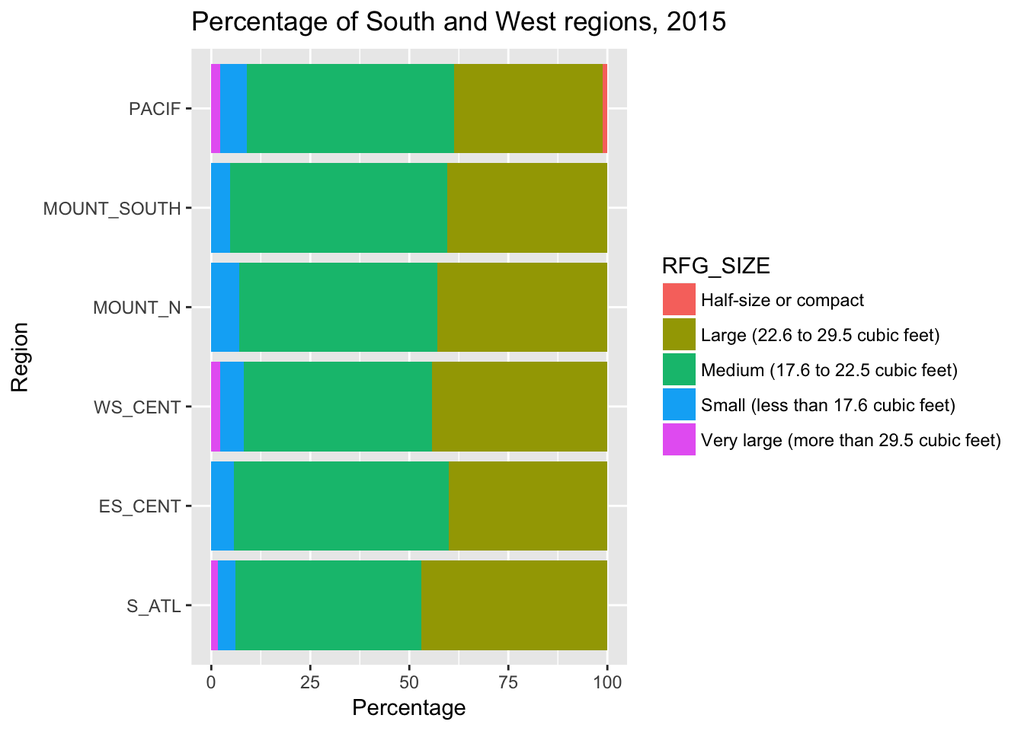

```r
PLOT_SW_SIZE_PERC
```

To better market, we compared the appliances of refrigerator types in homes in overall U.S regions by using the ggplot. The refrigerator types vary in half-size/compact, one door, three or more doors, two doors with bottom freezer, two doors with side by side, two doors with top freezer. The vertical axis is the number of housing unit and the horizontal axis is four regions, total northeast, total Midwest plus Middle Atlantic, Total South and Total West. It is clearly shown in the ggplot that most household in the U.S. use two doors refrigerators with top freezer and two doors refrigerator with side by side. Only few of the household does not use a refrigerator. There is no big difference between different regions in the types of refrigerator used by households.

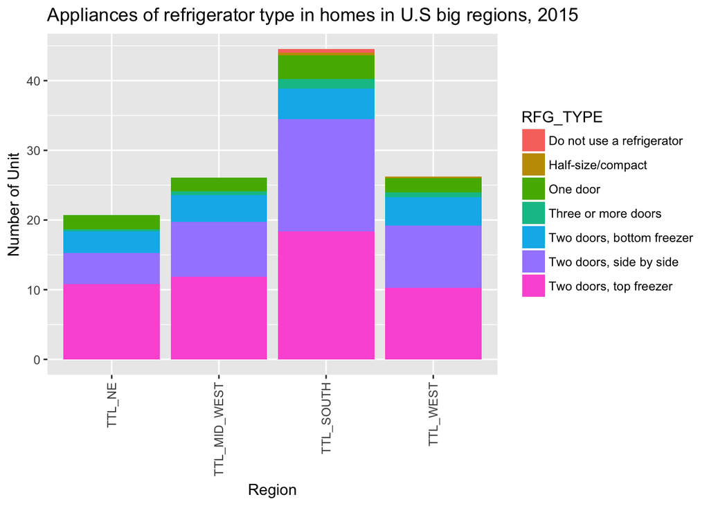

```r
PLOT_TYPE_TTL
```

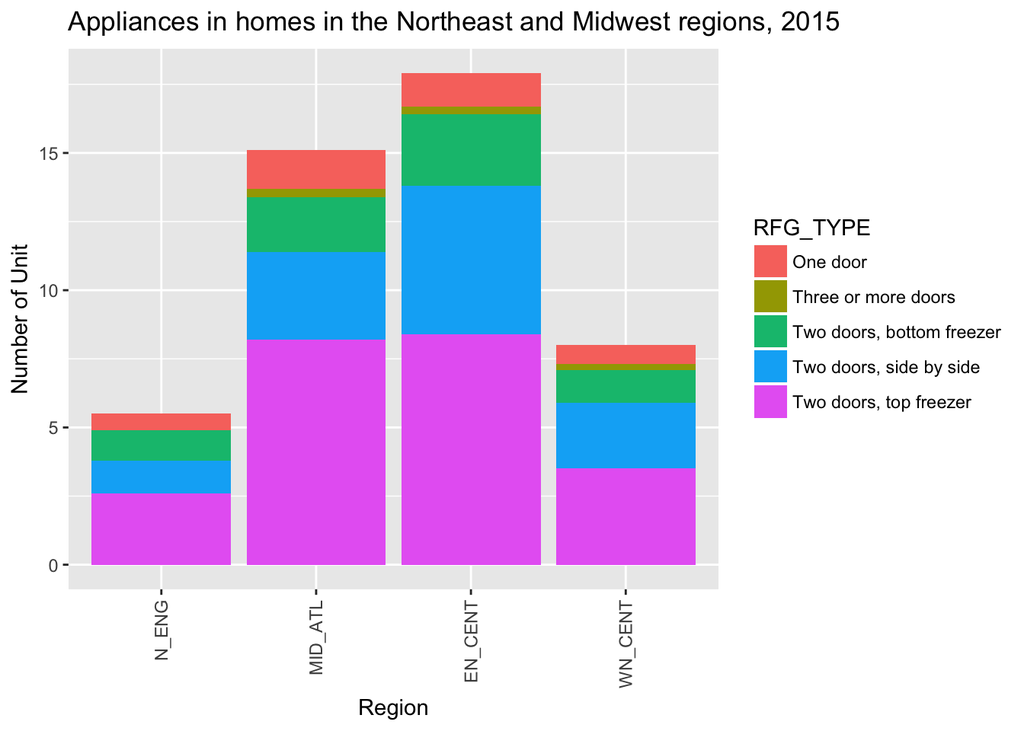

```r
PLOT_NM_TYPE
```

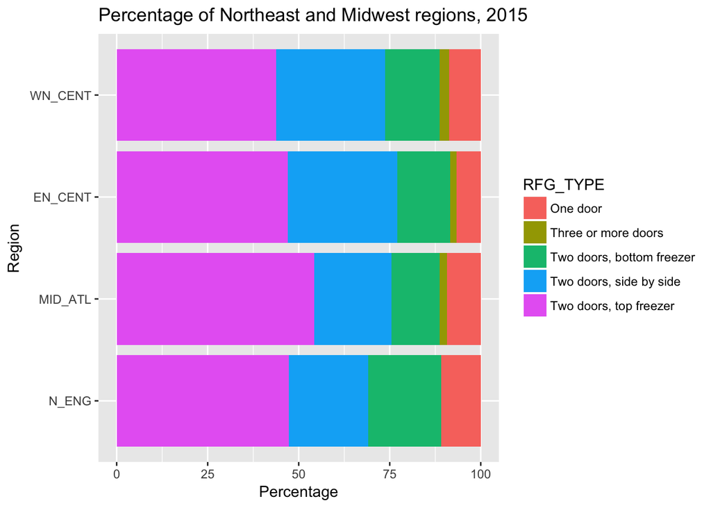

```r
PLOT_NM_TYPE_PERC
```

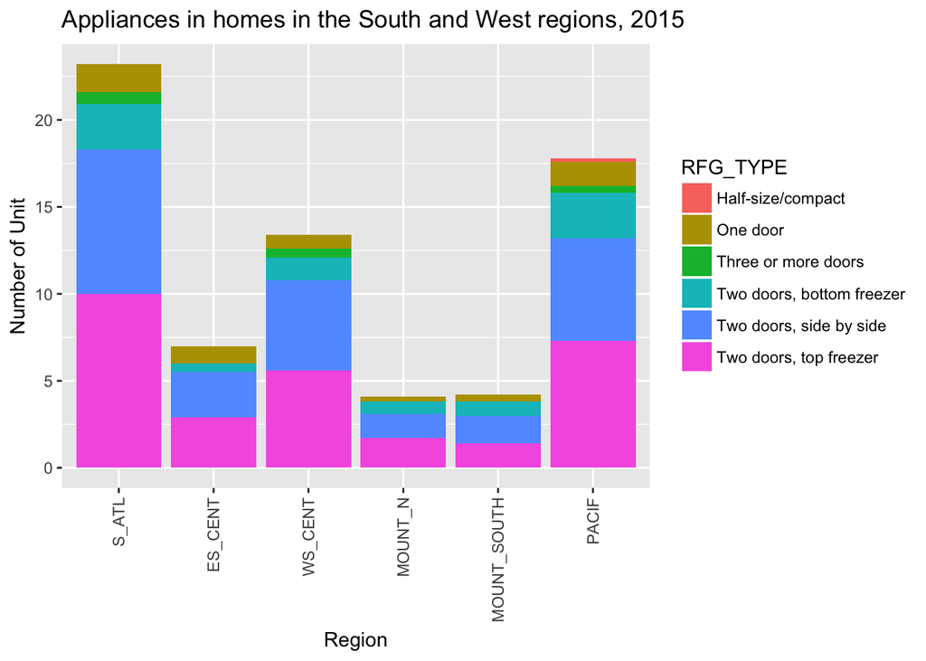

```r
PLOT_SW_TYPE
```

To confirm our analysis, the percentage of each refrigerator types used by households in different regions are calculated by the total number of household in different regions of the South and West. Ggplot is effectively used to compare the different preference of refrigerator type of all six regions. We found out that majority of the household of each region use the two doors refrigerators with top freezers and two doors refrigerator with side by side. Thus, we can conclude that two doors refrigerators with top freezers and two doors refrigerators with side by side should be marketed in all South and West regions.

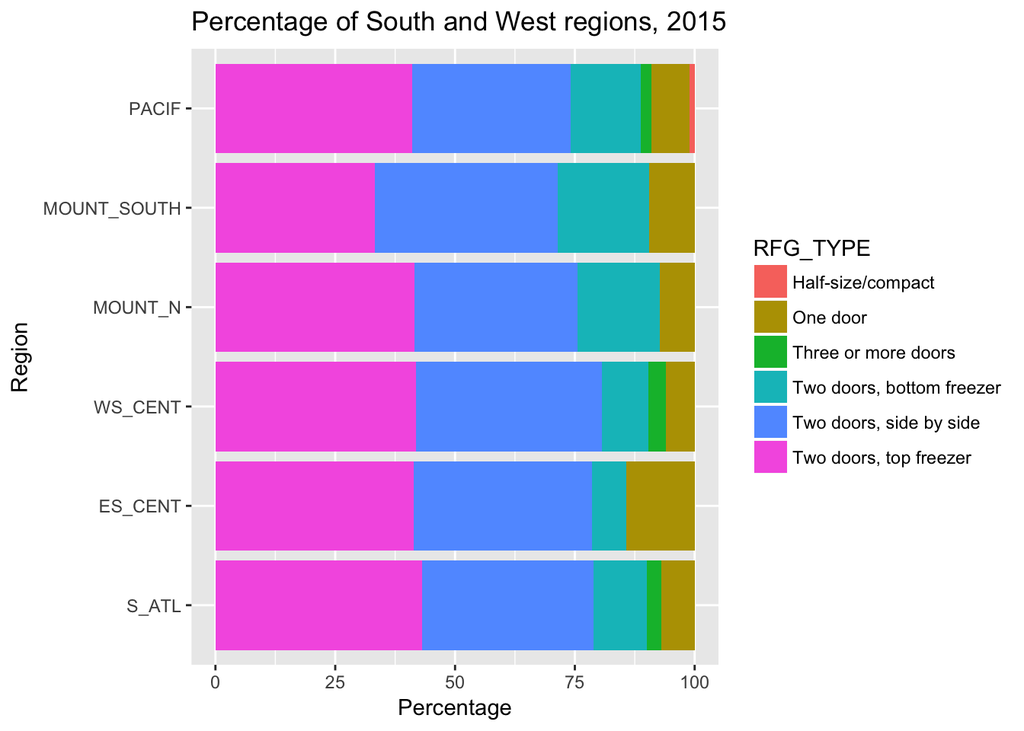

```r
PLOT_SW_TYPE_PERC
```

## Exploring for different income levels

```r
#Income Analysis Part
#downloading data

download.file(
  "https://www.eia.gov/consumption/residential/data/2015/hc/hc3.5.xlsx",
  "INCOME.xlsx", quiet = TRUE, mode = "wb")

#selecting data
sizeData <- read_excel("INCOME.xlsx", sheet = "data", range = "A108:J113",
                          col_names = FALSE, col_types = "text")

typeData <- read_excel("INCOME.xlsx", sheet = "data", range = "A115:J121",
                          col_names = FALSE, col_types = "text")
```

```r
#create duplicate data for future use
sizeData_1 <- sizeData

typeData_1 <- typeData


colnames(sizeData_1)      <- c("RFG_SIZE", "TTL_US", "LESS_20T",
                           "20_39T", "40_59T", "60_79T",
                           "80_99T", "100_119T","120_139T","140T_MORE")

colnames(typeData_1)      <- c("RFG_TYPE", "TTL_US", "LESS_20T",
                           "20_39T", "40_59T", "60_79T",
                           "80_99T", "100_119T","120_139T","140T_MORE")
```

```r
#Drop the Unnecessary Column

sizeData_2 <- within(sizeData_1, rm(TTL_US))
typeData_2 <- within(typeData_1, rm(TTL_US))



# COERCE FRIDGE TYPE COLUMN TO FACTOR
sizeData_2$RFG_SIZE    <- as.factor(sizeData_2$RFG_SIZE)
typeData_2$RFG_TYPE    <- as.factor(typeData_2$RFG_TYPE)



#cleaning data, mark unknown data as N/A
sizeData_2[, 2:9]    <- sapply(sizeData_2[, 2:9], as.numeric)
typeData_2[, 2:9]    <- sapply(typeData_2[, 2:9], as.numeric)
```

```r
#Melting Data
sizeData_3 <- as_tibble(melt(sizeData_2, id = 1))
typeData_3 <- as_tibble(melt(typeData_2, id = 1))

#Update column's name
names(sizeData_3)[2]    <- "Income Range"
names(sizeData_3)[3]    <- "Number of Unit"
names(typeData_3)[2]    <- "Income Range"
names(typeData_3)[3]    <- "Number of Unit"
```

```r
#getting sumn of data
sizeData_SUM <- aggregate(sizeData_3$`Number of Unit`,
                           by = list(category = sizeData_3$`Income Range`),
                           FUN=sum, na.rm = TRUE)

typeData_SUM <- aggregate(typeData_3$`Number of Unit`,
                           by = list(category = typeData_3$`Income Range`),
                           FUN=sum, na.rm = TRUE)




#Rename Columns
names(sizeData_SUM)[1] <- "Income Range"
names(sizeData_SUM)[2] <- "Total Number of Unit"

names(typeData_SUM)[1] <- "Income Range"
names(typeData_SUM)[2] <- "Total Number of Unit"



#Merge Sum with Original Data
sizeDataWithTotal <- merge(x = sizeData_3, y = sizeData_SUM, by = "Income Range", all = TRUE)
names(sizeDataWithTotal)[4] <- "Total Number of Unit by Income Range"
sizeDataWithTotal$Percentage <- 100*(sizeDataWithTotal$`Number of Unit` /sizeDataWithTotal$`Total Number of Unit by Income Range`)
rm(list = ls(pattern = "^T_"))

typeDataWithTotal <- merge(x = typeData_3, y = typeData_SUM, by = "Income Range", all = TRUE)
names(typeDataWithTotal)[4] <- "Total Number of Unit by Income Range"
typeDataWithTotal$Percentage <- 100*(typeDataWithTotal$`Number of Unit` /typeDataWithTotal$`Total Number of Unit by Income Range`)
rm(list = ls(pattern = "^T_"))
```

```r
#Start plotting
PLOT_SIZE_PERC <- ggplot(data = sizeDataWithTotal, aes(x = `Income Range`, y = Percentage)) +
                 geom_col(aes(fill = `RFG_SIZE`)) +
                 labs(title = "Refrigerator Size Percentage") +
                 coord_flip()

PLOT_SIZE <- ggplot(data = sizeDataWithTotal, aes(x = `Income Range`, y = `Number of Unit`)) +
             geom_col(aes(fill = `RFG_SIZE`)) +
             theme(axis.text.x = element_text(angle = 90, vjust = 0.5, hjust=1)) +
             labs(title = "Refrigerator Size Histogram by Income Range, 2015")

PLOT_TYPE_PERC <- ggplot(data = typeDataWithTotal, aes(x = `Income Range`, y = Percentage)) +
                 geom_col(aes(fill = `RFG_TYPE`)) +
                 labs(title = "Refrigerator Type Percentage") +
                 coord_flip()

PLOT_TYPE <- ggplot(data = typeDataWithTotal, aes(x = `Income Range`, y = `Number of Unit`)) +
             geom_col(aes(fill = `RFG_TYPE`)) +
             theme(axis.text.x = element_text(angle = 90, vjust = 0.5, hjust=1)) +
             labs(title = "Refrigerator Type Histogram by Income Range, 2015")
```

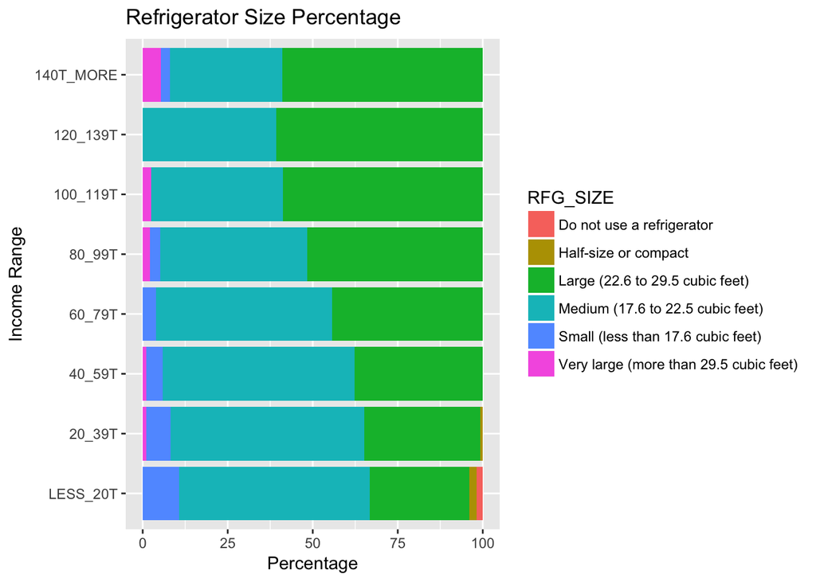

```r
#export result

PLOT_SIZE_PERC
```

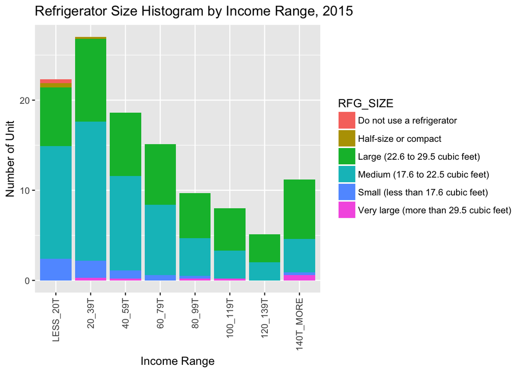

```r
PLOT_SIZE
```

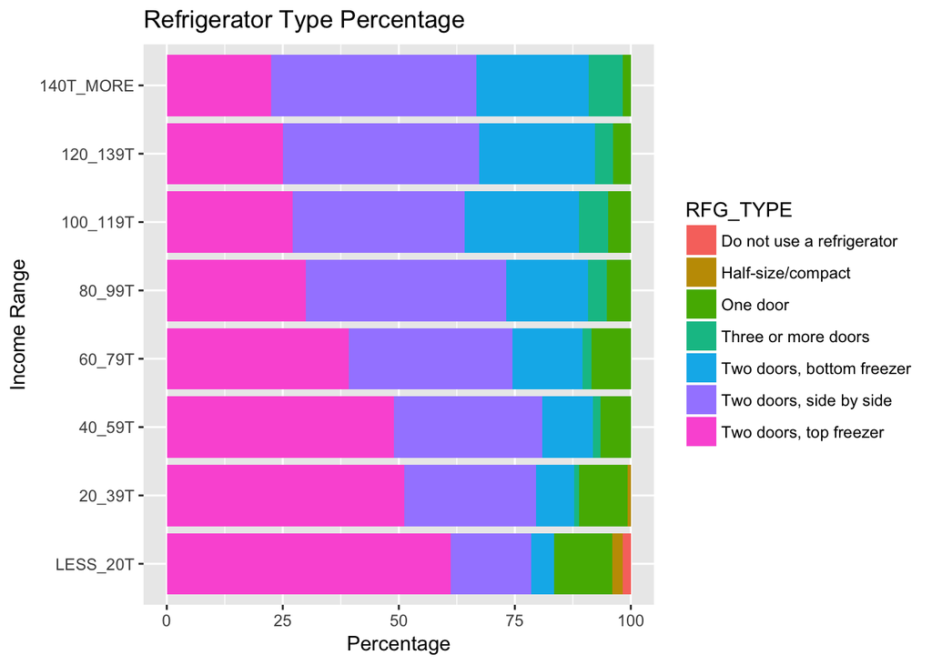

```r
PLOT_TYPE_PERC
```

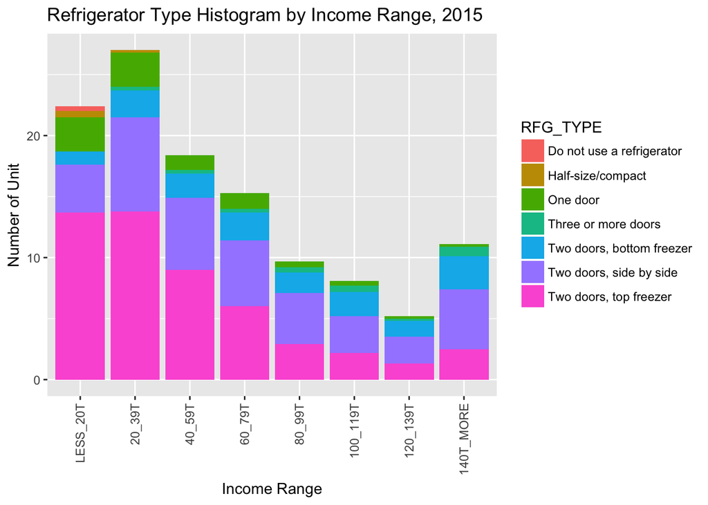

```r
PLOT_TYPE
```